# Practical Machine Learning Course_Project

Susann Vorberg

April 2015

# Data

The training data for this project is available here: https://d396qusza40orc.cloudfront.net/predmachlearn/pml-training.csv

The test data is available here (but is only used for the second part of the exercise): https://d396qusza40orc.cloudfront.net/predmachlearn/pml-testing.csv

```r
data_train <- read.csv("http://d396qusza40orc.cloudfront.net/predmachlearn/pml-training.csv", sep=",")
data_test  <- read.csv("http://d396qusza40orc.cloudfront.net/predmachlearn/pml-testing.csv", sep=",")
```

There are 19622 data samples in the training data set and 20 data samples in the test data set. The weight lifting exercises have been performed by 6 different subjects named: carlitos, pedro, adelmo, charles, eurico, jeremy. There are 5 different ways of doing the weight lifting exercise, that we want to predict. For predicting the exercise class one can use 159 predictors.

## Preparing the Environment

```r
set.seed(32323)
library(caret)
library(foreach)
library(doMC)
registerDoMC(cores=4)
```

## Preparing the data

First I divide the data into training data (~80%) that is used for tuning the models and test data(~20%) that I use to estimate the out of sample error.

```r
inTrain = createDataPartition(data_train$classe, p = 0.8)[[1]]
train = data_train[ inTrain,]
test  = data_train[-inTrain,]
```

The resulting training data set that I will use for cross validation has 15699 data samples and the resulting test data set has 3923 data samples.

From looking at the data I found that many predictors contain “NA” or blank values. Therefore I excluded these predictors from my training and test dataset.

> As can be read in the [article](http://groupware.les.inf.puc-rio.br/work.jsf?p1=11201), these descriptors represent summary statistics of the time series data that has been calculated by the authors via a sliding window approach.

```r
test  = test[ ,(colSums(is.na(train)) == 0) & (apply(train, 2, function(x) sum(x %in% "")) == 0)]
train = train[,(colSums(is.na(train)) == 0) & (apply(train, 2, function(x) sum(x %in% "")) == 0)]
```

Furthermore I excluded the predictors “X”, “user_name”, “raw_timestamp_part_1”, “raw_timestamp_part_2”, “cvtd_timestamp”, “new_window”, “num_window” as they are not relevant predictors according to the study design and the actual measured predictors.

> Again, as can be read in the article, the time stamps were used to calculate some of the summary statistics of the data that I excluded anyways.

```r
train = train[,-c(1:7)]
test  = test[,-c(1:7)]
```

This leaves me with 52 predictors.

# Preprocessing

## Standardizing: Centering and Scaling

Some machine learning methods are sensitive with respect to the range of the data. Therefore I will standardize the data (subtract mean and divide by standard deviation).

```r
preProcObj <- preProcess(train[,-ncol(train)],method=c("center","scale"))
trainStd <- predict(preProcObj, train[,-ncol(train)])
testStd  <- predict(preProcObj, test[,-ncol(test)])
```

Now, the values of the numeric predictors are standardized:

```r
summary(train[,1])
```

```
##    Min. 1st Qu.  Median    Mean 3rd Qu.    Max.
##  -28.90    1.10  114.00   64.84  123.00  162.00
```

```r
summary(trainStd[,1])
```

```
##    Min. 1st Qu.  Median    Mean 3rd Qu.    Max.
## -1.4940 -1.0160  0.7832  0.0000  0.9266  1.5480
```

## Remove near zero variances

Predictors with near zero variances can obscure the results of some machine learning methods, especially when applying cross validation and a predictor might only have a single unique value in one of the folds.

```r
nzv <- nearZeroVar(trainStd)
##number of near zero variables
length(nzv)
```

```
## [1] 0
```

Fortunately, none of the features has near-zero variances.

## Removing highly correlated features

Highly correlated features do not give any additional information that might be useful for prediction but rather might complicate model generation. Therefore I remove predictors that show correlation with other features above 0.9.

```r
Cor <- cor(trainStd)
highlyCorFeatures <- findCorrelation(Cor, cutoff = .9)
highlyCorFeatures
```

```
## [1] 10  1  9  8 19 46 31
```

There are 7 features that are highly correlated and can be excluded from the data set.

```r
trainStdCor <- trainStd[,-highlyCorFeatures]
testStdCor <- testStd[,-highlyCorFeatures]
trainStdCor$classe <- train$classe
testStdCor$classe <- test$classe
```

## PCA for dimensionality reduction

```r
trainOutliers <-  train[-c(which(train[,31] < -100), which(train[,38] < -1000)), ]
preProc       <- preProcess(trainOutliers[,-ncol(trainOutliers)], method="pca", thresh=0.9)
print(preProc)
```

```
##
## Call:
## preProcess.default(x = trainOutliers[, -ncol(trainOutliers)], method
##  = "pca", thresh = 0.9)
##
## Created from 15698 samples and 52 variables
## Pre-processing: principal component signal extraction, scaled, centered
##
## PCA needed 20 components to capture 90 percent of the variance
```

```r
trainPC <- predict(preProc,trainOutliers[,-ncol(trainOutliers)])
testPC <- predict(preProc,test[,-ncol(train)])
trainPC$classe <- train[-c(which(train[,31] < -100), which(train[,38] < -1000)),'classe']
testPC$classe <- test$classe
```

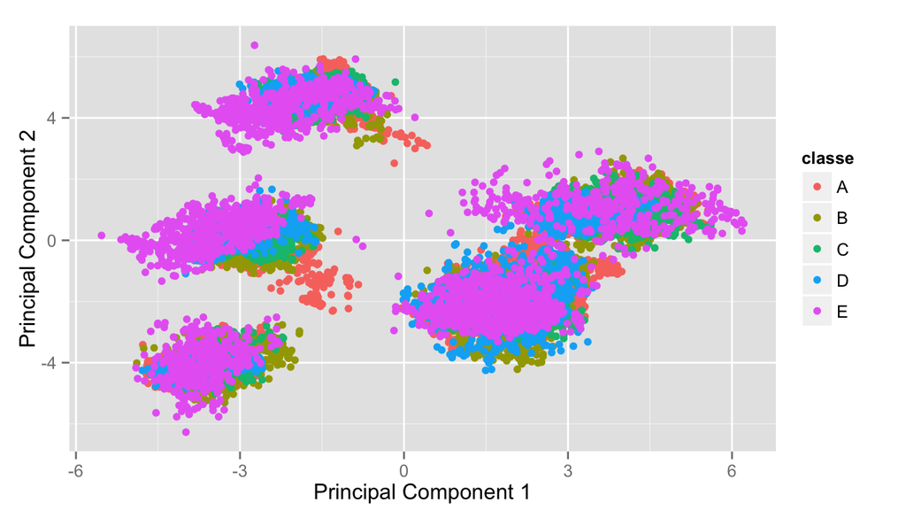

# Generating Models

```r
fitControl <- trainControl(## 5-fold CV
                           method = "cv",
                           number = 5,
                           ##for parallalization
                           allowParallel=TRUE
                           )
```

## Random Forest

```r
RFModel         <- train(classe ~., data=train, method="rf", trControl = fitControl)
print(RFModel)
print(RFModel$finalModel)
confusionMatrix(RFModel)
pred_RF <- predict(RFModel,test)
confusionMatrix(pred_RF,test$classe)

RFModel_StdCor  <- train(classe ~., data=trainStdCor, method="rf", trControl = fitControl)
print(RFModel_StdCor)
print(RFModel_StdCor$finalModel)
confusionMatrix(RFModel_StdCor)
pred_RF_StdCor <- predict(RFModel_StdCor,testStdCor)
confusionMatrix(pred_RF_StdCor,testStdCor$classe)

RFModel_PC      <- train(classe ~., data=trainPC, method="rf", trControl = fitControl)
print(RFModel_PC)
print(RFModel_PC$finalModel)
confusionMatrix(RFModel_PC)
pred_RF_PC <- predict(RFModel_PC,testPC)
confusionMatrix(pred_RF_PC,testPC$classe)
```

[output not shown]

### LDA

```r
LDA_Model = train(classe ~., data=train, method="lda", trControl = fitControl)
print(LDA_Model)
confusionMatrix(LDA_Model)
pred_LDA <- predict(LDA_Model,test)
confusionMatrix(pred_LDA,test$classe)

LDA_Model_StdCor = train(classe ~., data=trainStdCor, method="lda", trControl = fitControl)
print(LDA_Model_StdCor)
confusionMatrix(LDA_Model_StdCor)
pred_LDA_StdCor <- predict(LDA_Model_StdCor,testStdCor)
confusionMatrix(pred_LDA_StdCor,testStdCor$classe)

LDA_Model_PC     = train(classe ~., data=trainPC, method="lda", trControl = fitControl)
print(LDA_Model_PC)
confusionMatrix(LDA_Model_PC)
pred_LDA_PC <- predict(LDA_Model_PC, testPC)
confusionMatrix(pred_LDA_PC,testPC$classe)
```

[output not shown]

## Rpart

```r
Tree_Model = train(classe ~., data=train, method="rpart",trControl = fitControl)
print(Tree_Model)
confusionMatrix(Tree_Model)
pred_Tree <- predict(Tree_Model, test)
confusionMatrix(pred_Tree,test$classe)

Tree_Model_StdCor = train(classe ~., data=trainStdCor, method="rpart",trControl = fitControl)
print(Tree_Model_StdCor)
confusionMatrix(Tree_Model_StdCor)
pred_Tree_StdCor <- predict(Tree_Model_StdCor, testStdCor)
confusionMatrix(pred_Tree_StdCor,testStdCor$classe)


Tree_Model_PC     = train(classe ~., data=trainPC, method="rpart", trControl = fitControl)
print(Tree_Model_PC)
confusionMatrix(Tree_Model_PC)
pred_Tree_PC <- predict(Tree_Model_PC, testPC)
confusionMatrix(pred_Tree_PC,testPC$classe)
```

[output not shown]